# CodingProject1

```python
# name: Hsin Yu Chen
# date: 2/9/2024
# course number: CSC647-01
# CP #1 This coding project manipulates single-qubit states and runs local simulations.
```

```python
from qiskit import QuantumCircuit, transpile, assemble, execute
from qiskit.visualization import plot_histogram, plot_bloch_multivector, circuit_drawer, plot_distribution
from qiskit.quantum_info import Statevector, Operator
from qiskit_aer import Aer
import numpy as np
import matplotlib.pyplot as plt
```

### Circuit #1:

```
Statevector: Statevector([1.+0.j, 0.+0.j],
            dims=(2,))
```

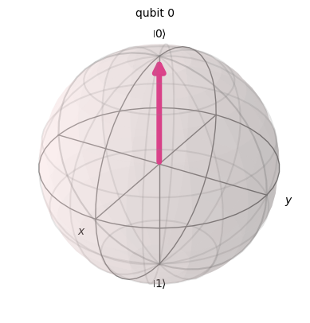

```python
# A single qubit initialized to the |0> state
qc1 = QuantumCircuit(1)

# Add a measurement gate to the circuit
qc1.measure_all()

# Save the statevector before running the simulator
qc1.save_statevector()
# Execute the circuit using the Qiskit statevector simulator (aer_simulator_statevector)
simulator1 = Aer.get_backend('aer_simulator_statevector')
result1 = simulator1.run(qc1).result()

# Query the simulator results to obtain the state vector, and print out the state vector
statevector1 = result1.get_statevector(qc1)
print("Statevector:", statevector1)
# Visualize the quantum state using a Bloch Sphere
plot_bloch_multivector(statevector1)
```

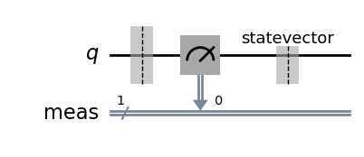

```python
qc1.draw(output='mpl', style='iqp')
```

#### Answer for Circuit #1:

The observed/measured value of the quantum state for this single-qubit circuit is |0⟩, which is represented by a point on the Bloch Sphere along the +z-axis.

### Circuit #2:

```
Measurement counts: {'1': 1.0}
Statevector: Statevector([0.+0.j, 1.+0.j],
            dims=(2,))
```

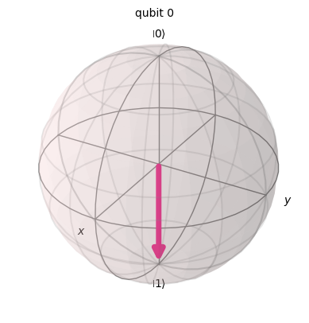

```python
# A single qubit initialized to the |0> state
qc2 = QuantumCircuit(1)
# Apply a quantum gate that will transform the invert the quantum state, eg., from |0> to |1> or conversely from |1> to |0>
qc2.x(0)
qc2.save_statevector()

# Execute the circuit using the Qiskit statevector simulator (aer_simulator_statevector)
simulator2 = Aer.get_backend('aer_simulator_statevector')
result2 = simulator2.run(qc2).result()

# Query the simulator results to obtain then print out the values measured
counts2 = result2.get_counts(qc2)
print("Measurement counts:", counts2)

# Query the simulator results to obtain the state vector
statevector2 = result2.get_statevector(qc2)
print("Statevector:", statevector2)

# Visualize the quantum state using a Bloch Sphere
plot_bloch_multivector(statevector2)
```

```python
qc2.draw(output='mpl', style='iqp')
```

[output not shown]

#### Answer for Circuit #2:

Circuit #2 applies the X gate. It flips the |0⟩ state to |1⟩, changing the quantum state of the qubit. The observed/measured value of the quantum state for Circuit #2 is |1⟩, which is represented by a point on the Bloch Sphere along the -z-axis. The X gate flips the |0⟩ state to |1⟩.

### Circuit #3:

```
State Statevector: Statevector([1.+0.j, 0.+0.j],
            dims=(2,))
Measurement Counts: {'1': 494, '0': 530}
```

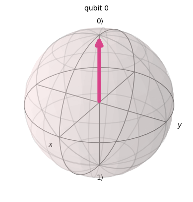

```python
# A single qubit initialized to the |0> state
qc3 = QuantumCircuit(1)
# Apply a quantum gate that creates a state of superposition, e.g, equal probabilities of |0> and |1>
qc3.h(0)
qc3.measure_all()
qc3.save_statevector()

# Execute the circuit using the Qiskit aer_simulator backend (aer_simulator)
simulator3 = Aer.get_backend('aer_simulator')
results3 = simulator3.run(qc3).result()

# Query the simulator results to obtain the state vector and counts
statevector3 = results3.get_statevector()
print("State Statevector:", statevector3)

# Get the counts
counts3 = results3.get_counts()
print("Measurement Counts:", counts3)

# Visualize the quantum state using a Bloch Sphere
plot_bloch_multivector(statevector3)
```

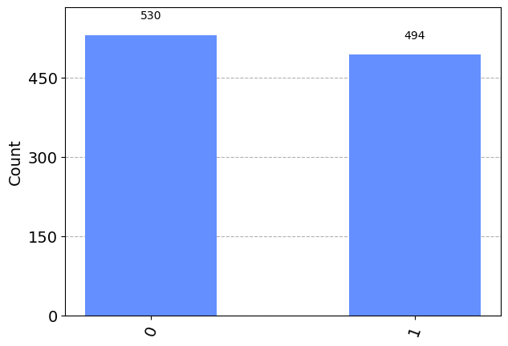

```python
# Make a histogram bar chart plot of the counts.
plot_histogram(counts3)
```

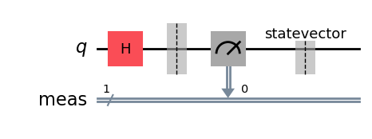

```python
qc3.draw(output='mpl', style='iqp')
```

#### Answer for Circuit #3:

No, I do not see the same results each time. The Bloch Sphere plot and histogram of counts will vary due to the probabilistic nature of quantum measurements. Quantum computations involve randomness, and when a qubit is measured, it collapses to either the |0⟩ or |1⟩ state with equal probabilities, resulting in different outcomes in different runs of the circuit.

### Circuit #4

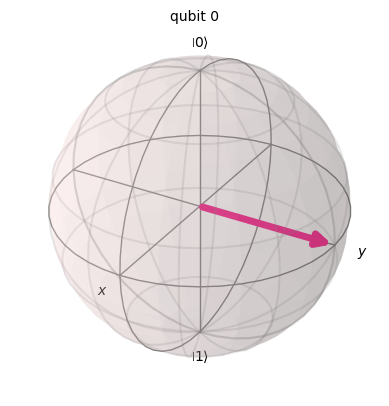

```python
# A single qubit initialized to the |0> state
qc4 = QuantumCircuit(1,1)
# Apply one or more quantum gates such that the state vector, when plotted with a Bloch sphere, points towards the +Y axis. Remember the +z axis is at the North pole, and the x- and y-axes form a plane of zero latitude positioned at the equator.
# Apply X-axis rotation to bring the state to the +Y axis
qc4.rx(-np.pi/2, 0)

qc4.save_statevector()

# Execute the circuit using the Qiskit statevector simulator (aer_simulator_statevector)
simulator4 = Aer.get_backend('aer_simulator_statevector')
result4 = simulator4.run(qc4).result()
# Query the simulator results to obtain the state vector
statevector4 = result4.get_statevector(qc4)
# Visualize the quantum state using a Bloch Sphere
plot_bloch_multivector(statevector4)
```

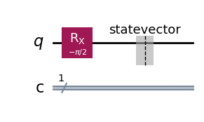

```python
qc4.draw(output='mpl', style='iqp')
```

#### Answer for Circuit #4:

Difference: The key difference is the application of gates that specifically rotate the state towards the +Y axis on the Bloch Sphere. The X-axis rotation in Circuit #4 achieves this, unlike other circuits that may prepare states pointing to |0⟩, |1⟩, or a superposition along the equator.

### Circuit 5:

[output not shown]

[figure not shown]

```python
qc5 = QuantumCircuit(1)

initial_statevector = [0, 1]

qc5.initialize(initial_statevector, 0)
qc5.save_statevector()

simulator5 = Aer.get_backend('aer_simulator_statevector')
before_gates_statevector = simulator5.run(qc5).result().get_statevector()
# Print the statevector before applying gates
print("Statevector before applying gates:", before_gates_statevector)

qc5.z(0)
qc5.h(0)
qc5.z(0)

final_statevector = simulator5.run(qc5).result().get_statevector()

# Print the statevector after applying gates
print("Statevector after applying gates:", final_statevector)

# Check if the initial and final statevectors are the same
if np.allclose(before_gates_statevector, final_statevector):
    print("The circuit successfully implements the Identity transformation.")
else:
    print("The circuit does not implement the Identity transformation.")

plot_bloch_multivector(final_statevector)
```

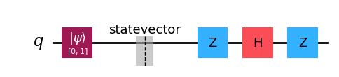

```python
qc5.draw(output='mpl', style='iqp')
```